# Network inference

Author

Mariam Rahali Masbouri

Published

May 6, 2026

In this file, we will perform network inference on the gut microbiota datasets using three different methods: LIMITS, FlashWeave and BEEM-Static. We will first import the relevant datasets from the dysbiotic cohorts (that is, those pertaining to IBD, IBS, CRC, and CDI) as well as the healthy cohorts from the Human Microbiome Project (HMPv13 and HMPv35), NIBIOHN and MORINAGA cohorts, and a “diet intervention” cohort as well. We describe first each tool and its implementation in the following sections, and then we will compare the results obtained from each method in a final section.

For each tool, the following metrics will be computed:

- **Number of edges**: The total number of edges in the inferred network.
- **Proportion of positive edges (PEP)**: Defined as the number of positive edges divided by the total number of edges in the inferred network.
- **Richness**: The number of taxa in the microbiota dataset.
- **Shannon diversity**: Defined as $H' = -\sum_{i=1}^S p_i \ln(p_i)$, where $p_i$ is the relative abundance of taxon $i$ and $S$ is the total number of taxa in the dataset.
- **Sheldon evenness**: Defined as $E = \frac{H'}{\ln(S)}$, where $H'$ is the Shannon diversity and $S$ is the total number of taxa in the dataset.
- **Net interactions**: computed as the difference between the sum of positive and negative edge weights, normalized by the total sum of edge weights in the inferred network. This metric quantifies the balance between positive and negative interactions, ranging from -1 (all interactions negative) to +1 (all interactions positive). Mathematically:

$$\rho = \frac{\sum_{i \neq j} (w_{ij}^+ + w_{ij}^-)}{\sum_{i \neq j} (w_{ij}^+ - w_{ij}^-)}$$

where $w_{ij}^+$ and $w_{ij}^-$ denote the positive and negative edge weights between taxa i and j respectively.For directed inference tools (BEEM-Static, LIMITS), both directions $w_{ij}$ and $w_{ji}$ are included. For undirected tools (FlashWeave), each pair is counted once. The ratio remains comparable across tools as any double-counting cancels in the ratio.

The following parameters were set for network inference tools:

- *FlashWeave*: FlashWeave is a network inference tool developed by the Von Mering research group (Tackmann et al., 2019). It operates within a Probabilistic Graphical Model framework, enabling the integration of metadata and the prediction of direct microbial interactions from heterogeneous microbial abundance datasets.

```r
library(JuliaCall)
julia_setup(JULIA_HOME = "C:/Users/maria/.julia/juliaup/julia-1.12.5+0.x64.w64.mingw32/bin")
julia_eval('using FlashWeave')
```

```r
julia_eval('import FlashWeave: learn_network, save_network, load_data')
```

```r
julia_eval('println(methods(learn_network))')
```

As per the original article, FlashWeave was run with its default parameters, and `heterogeneous = FALSE` was chosen, in accordance with the original article. We run FlashWeave on bootstrap iterations with the function `run_network_bootstrap()` that we defined in the R/ directory. This function takes as input a dataset in matrix form, a network inference function (in this case, `run_flashweave()`, which is also defined in the R/ directory), and the parameters for the bootstrap iterations. The function returns a list of results for each bootstrap iteration, which can be used to compute the statistics of interest (PEP, Sheldon evenness, Shannon diversity, richness, and net interactions), summarized with the function `get_stats_df()`. The parameters for the bootstrap iterations are as follows: `n_bootstrap = 100`, `subsample_pcts = c(0.6, 0.7, 0.8)`, `max_attempts = 120`, and no prevalence threshold. Additionally, the parameters from `get_stats_df()` are set to `symmetric = TRUE` since FlashWeave returns undirected edges.

# Importing the MAE object

```r
mae_file <-
  fs::dir_ls(str_c(data_dir(), "/02-processed-data"), regexp = "MAE_processed_.*\\.rds$") |>
  sort(decreasing = TRUE) |>
  magrittr::extract(1)


cat(str_c("Loading MultiAssayExperiment from: 00_data/", mae_file |> str_remove(data_dir()), "\n"))
```

```
Loading MultiAssayExperiment from: 00_data//02-processed-data/MAE_processed_20260421.rds
```

```r
mae <- readRDS(mae_file)

rm(mae_file)

mae
```

```
A MultiAssayExperiment object of 8 listed
 experiments with user-defined names and respective classes.
 Containing an ExperimentList class object of length 8:
 [1] IBD: SummarizedExperiment with 432 rows and 1630 columns
 [2] IBS: SummarizedExperiment with 1912 rows and 469 columns
 [3] CDI: SummarizedExperiment with 805 rows and 534 columns
 [4] CRC: SummarizedExperiment with 837 rows and 575 columns
 [5] IBD_FRANZOSA: SummarizedExperiment with 201 rows and 220 columns
 [6] CRC_ZELLER: SummarizedExperiment with 652 rows and 156 columns
 [7] CRC_WIRBEL: SummarizedExperiment with 537 rows and 125 columns
 [8] CRC_VOGTMANN: SummarizedExperiment with 540 rows and 110 columns
Functionality:
 experiments() - obtain the ExperimentList instance
 colData() - the primary/phenotype DataFrame
 sampleMap() - the sample coordination DataFrame
 `$`, `[`, `[[` - extract colData columns, subset, or experiment
 *Format() - convert into a long or wide DataFrame
 assays() - convert ExperimentList to a SimpleList of matrices
 exportClass() - save data to flat files
```

# Network inference for main cohorts

## IBD cohort (Lloyd-Price et al. 2019)

```r
tmp <-
  mae[["IBD"]] |>
  assay() |>
  t() |>
  as.data.frame() |>
  rownames_to_column("uid") |>
  pivot_longer(-uid, names_to = "taxon", values_to = "rel_ab") |>
  left_join(
    mae[["IBD"]] |> colData() |> as_tibble(rownames = "uid") |> select(uid, pid, visit_num, diagnosis),
    by = join_by(uid)
  )
```

```r
tmp_healthy <- tmp |> filter(diagnosis == "nonIBD")
tmp_diseased <- tmp |> filter(diagnosis == "UC" | diagnosis == "CD")

# for healthy samples

healthy_df <-
  tmp_healthy |>
  select(uid, taxon, rel_ab) |>
  pivot_wider(names_from = taxon, values_from = rel_ab) |>
  column_to_rownames("uid") |>
  t()

# for diseased samples

diseased_df <-
  tmp_diseased |>
  select(uid, taxon, rel_ab) |>
  pivot_wider(names_from = taxon, values_from = rel_ab) |>
  column_to_rownames("uid") |>
  t()
```

### FlashWeave

```r
res_healthy <- run_network_bootstrap(healthy_df, run_fn = run_flashweave, n_bootstrap = 100, subsample_pcts = c(0.6, 0.7, 0.8), max_attempts = 120, prevalence_threshold = 0)

res_diseased <- run_network_bootstrap(diseased_df, run_fn = run_flashweave, n_bootstrap = 100, subsample_pcts = c(0.6, 0.7, 0.8), max_attempts = 120, prevalence_threshold = 0)
```

We save the results in an RDS file for later use.

```r
saveRDS(res_healthy, file = str_c(result_dir(), "/flashweave_res_healthy_IBD_20260419.rds"))

beepr::beep(1)

saveRDS(res_diseased, file = str_c(result_dir(), "/flashweave_res_diseased_IBD_20260419.rds"))

beepr::beep(1)
```

```r
res_healthy <- readRDS(file = str_c(result_dir(), "/flashweave_res_healthy_IBD_20260419.rds"))

res_diseased <- readRDS(file = str_c(result_dir(), "/flashweave_res_diseased_IBD_20260419.rds"))
```

```r
df_res_healthy <- get_stats_df(res_healthy, symmetric = TRUE)
df_res_diseased <- get_stats_df(res_diseased, symmetric = TRUE)

df_res <-
  bind_rows(
    df_res_healthy |> mutate(group = "Healthy"),
    df_res_diseased |> mutate(group = "Diseased")
  )
```

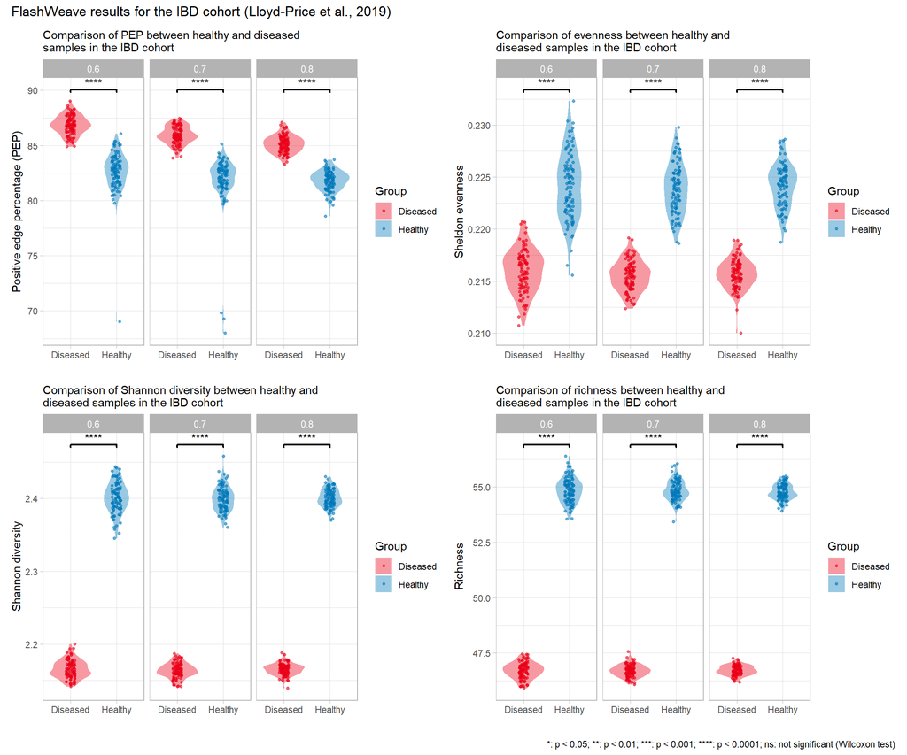

```r
plot_diversity_results(df_res, cohort_name = "IBD") + patchwork::plot_annotation(title = "FlashWeave results for the IBD cohort (Lloyd-Price et al., 2019)", caption = "*: p < 0.05; **: p < 0.01; ***: p < 0.001; ****: p < 0.0001; ns: not significant (Wilcoxon test)")
```

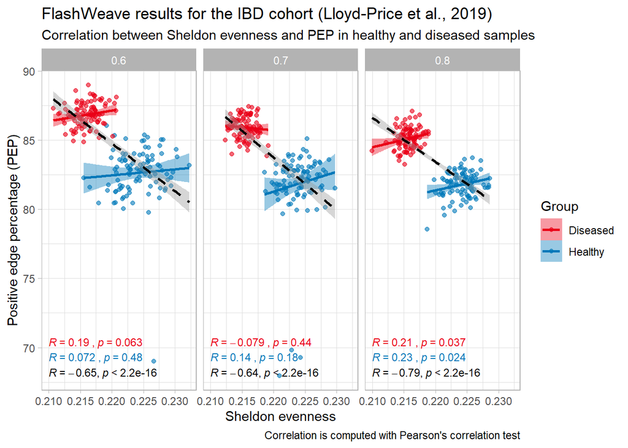

```r
plot_correlation_results(df_res, variable_name = "pep") + labs(x = "Sheldon evenness", y = "Positive edge percentage (PEP)", color = "Group", fill = "Group", title = "FlashWeave results for the IBD cohort (Lloyd-Price et al., 2019)", subtitle = "Correlation between Sheldon evenness and PEP in healthy and diseased samples", caption = "Correlation is computed with Pearson's correlation test")
```

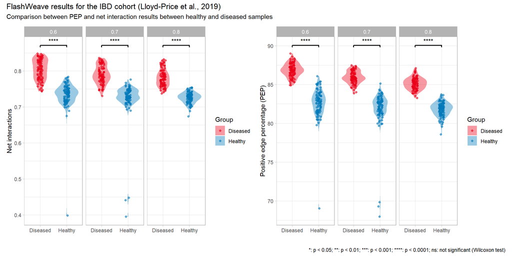

```r
plot_network_results(df_res) + patchwork::plot_annotation(title = "FlashWeave results for the IBD cohort (Lloyd-Price et al., 2019)", subtitle = "Comparison between PEP and net interaction results between healthy and diseased samples", caption = "*: p < 0.05; **: p < 0.01; ***: p < 0.001; ****: p < 0.0001; ns: not significant (Wilcoxon test)")
```

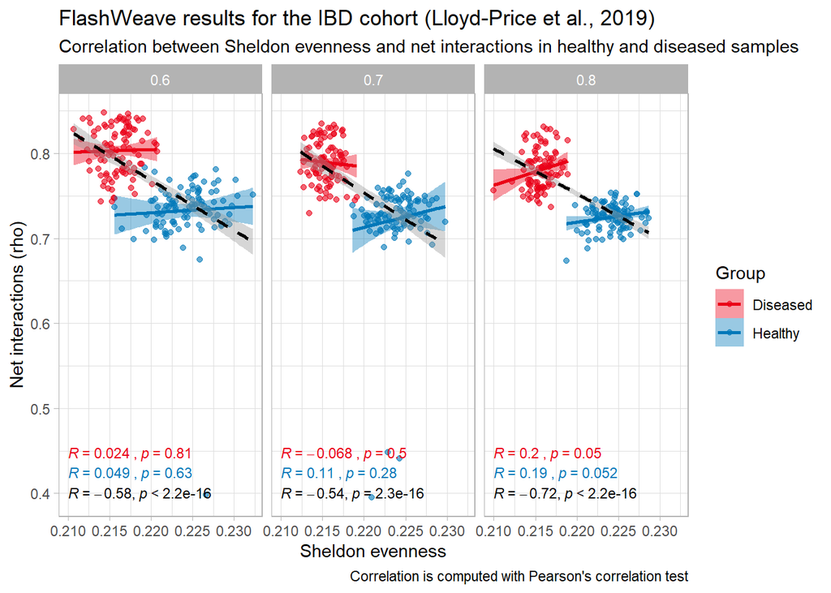

```r
plot_correlation_results(df_res, variable_name = "rho") + labs(x = "Sheldon evenness", y = "Net interactions (rho)", color = "Group", fill = "Group", title = "FlashWeave results for the IBD cohort (Lloyd-Price et al., 2019)", subtitle = "Correlation between Sheldon evenness and net interactions in healthy and diseased samples", caption = "Correlation is computed with Pearson's correlation test")
```

### BEEM-Static

```r
# import file from cluster

res_healthy <- readRDS(file = str_c(result_dir(), "/beem_res_healthy_IBD_20260414.rds"))
res_diseased <- readRDS(file = str_c(result_dir(), "/beem_res_diseased_IBD_20260414.rds"))
```

```r
df_res_healthy <- get_stats_df(res_healthy, symmetric = FALSE)
df_res_diseased <- get_stats_df(res_diseased, symmetric = FALSE)
```

```r
df_res <-
  bind_rows(
    df_res_healthy |> mutate(group = "Healthy"),
    df_res_diseased |> mutate(group = "Diseased")
  )
```

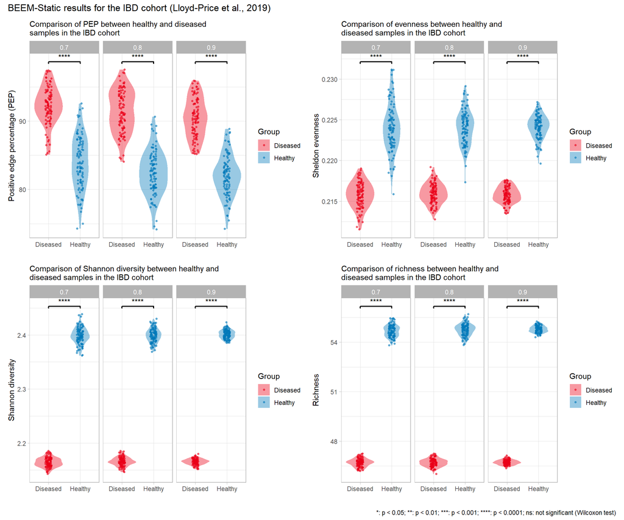

```r
plot_diversity_results(df_res, cohort_name = "IBD") + patchwork::plot_annotation(title = "BEEM-Static results for the IBD cohort (Lloyd-Price et al., 2019)", caption = "*: p < 0.05; **: p < 0.01; ***: p < 0.001; ****: p < 0.0001; ns: not significant (Wilcoxon test)")
```

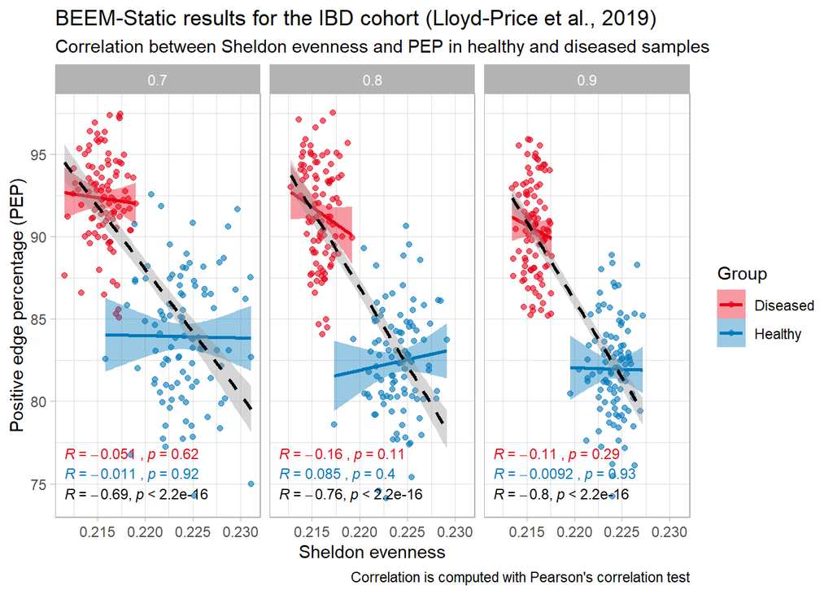

```r
plot_correlation_results(df_res, variable_name = "pep") + labs(x = "Sheldon evenness", y = "Positive edge percentage (PEP)", color = "Group", fill = "Group", title = "BEEM-Static results for the IBD cohort (Lloyd-Price et al., 2019)", subtitle = "Correlation between Sheldon evenness and PEP in healthy and diseased samples", caption = "Correlation is computed with Pearson's correlation test")
```

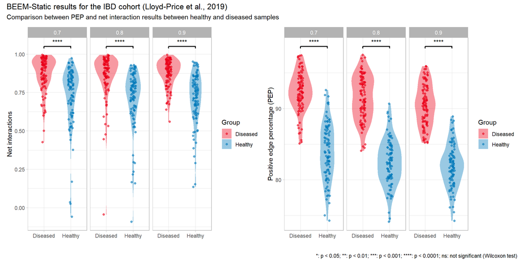

```r
plot_network_results(df_res) + patchwork::plot_annotation(title = "BEEM-Static results for the IBD cohort (Lloyd-Price et al., 2019)", subtitle = "Comparison between PEP and net interaction results between healthy and diseased samples", caption = "*: p < 0.05; **: p < 0.01; ***: p < 0.001; ****: p < 0.0001; ns: not significant (Wilcoxon test)")
```

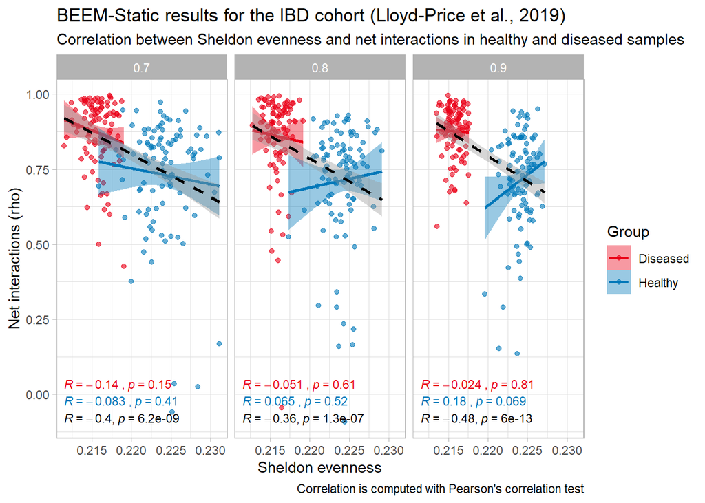

```r
plot_correlation_results(df_res, variable_name = "rho") + labs(x = "Sheldon evenness", y = "Net interactions (rho)", color = "Group", fill = "Group", title = "BEEM-Static results for the IBD cohort (Lloyd-Price et al., 2019)", subtitle = "Correlation between Sheldon evenness and net interactions in healthy and diseased samples", caption = "Correlation is computed with Pearson's correlation test")
```

## CDI cohort (Ferretti et al., 2023)

```r
tmp <-
  mae[["CDI"]] |>
  assay() |>
  t() |>
  as.data.frame() |>
  rownames_to_column("uid") |>
  pivot_longer(-uid, names_to = "taxon", values_to = "count") |>
  group_by(uid) |>
  mutate(rel_ab = count/sum(count)) |>
  left_join(
    mae[["CDI"]] |> colData() |> as_tibble(rownames = "uid") |> select(uid, status, subject_disease_status),
    by = join_by(uid)
  ) |>
  filter(subject_disease_status == "CDI" | subject_disease_status == "CTR")
```

```r
tmp_healthy <- tmp |> filter(subject_disease_status == "CTR")
tmp_diseased <- tmp |> filter(subject_disease_status == "CDI")

# for healthy samples

healthy_df <-
  tmp_healthy |>
  select(uid, taxon, rel_ab) |>
  pivot_wider(names_from = taxon, values_from = rel_ab) |>
  column_to_rownames("uid") |>
  t()

# for diseased samples

diseased_df <-
  tmp_diseased |>
  select(uid, taxon, rel_ab) |>
  pivot_wider(names_from = taxon, values_from = rel_ab) |>
  column_to_rownames("uid") |>
  t()
```

### FlashWeave

In the chunk code below, we run FlashWeave on all taxa for healthy and diseased samples separately, with the following parameters: `n_bootstrap = 100`, `subsample_pcts = c(0.6, 0.7, 0.8)`, `max_attempts = 120`. This means that in each bootstrap iteration, we will subsample the data at different percentages (60%, 70%, and 80%) and run FlashWeave on the subsampled data.

```r
res_healthy <- run_network_bootstrap(healthy_df, run_fn = run_flashweave, n_bootstrap = 100, subsample_pcts = c(0.6, 0.7, 0.8), max_attempts = 120, prevalence_threshold = 0)

beepr::beep(2)

res_diseased <- run_network_bootstrap(diseased_df, run_fn = run_flashweave, n_bootstrap = 100, subsample_pcts = c(0.6, 0.7, 0.8), max_attempts = 120, prevalence_threshold = 0)

beepr::beep(2)

saveRDS(res_healthy, file = str_c(result_dir(), "/flashweave_res_healthy_CDI_20260419.rds"))
saveRDS(res_diseased, file = str_c(result_dir(), "/flashweave_res_diseased_CDI_20260419.rds"))

beepr::beep(2)
```

We load the results in the chunk code below.

```r
res_healthy <- readRDS(file = str_c(result_dir(), "/flashweave_res_healthy_CDI_20260419.rds"))
res_diseased <- readRDS(file = str_c(result_dir(), "/flashweave_res_diseased_CDI_20260419.rds"))
```

The results are obtained in the chunk code below.

```r
df_res_healthy <- get_stats_df(res_healthy, symmetric = TRUE)
df_res_diseased <- get_stats_df(res_diseased, symmetric = TRUE)

df_res <-
  bind_rows(
    df_res_healthy |> mutate(group = "Healthy"),
    df_res_diseased |> mutate(group = "Diseased")
  )
```

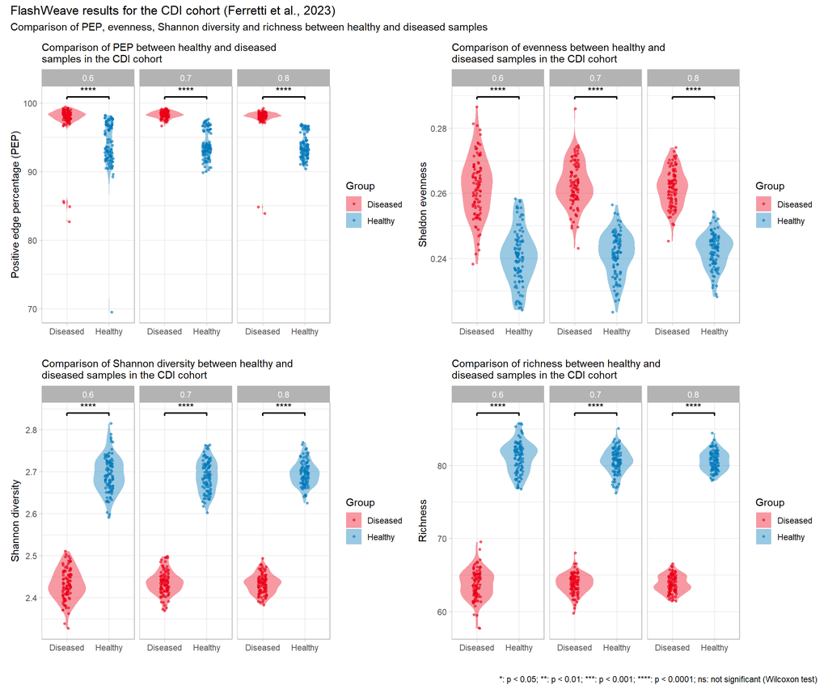

```r
plot_diversity_results(df_res, cohort_name = "CDI")+ patchwork::plot_annotation(title = "FlashWeave results for the CDI cohort (Ferretti et al., 2023)", subtitle = "Comparison of PEP, evenness, Shannon diversity and richness between healthy and diseased samples", caption = "*: p < 0.05; **: p < 0.01; ***: p < 0.001; ****: p < 0.0001; ns: not significant (Wilcoxon test)")
```

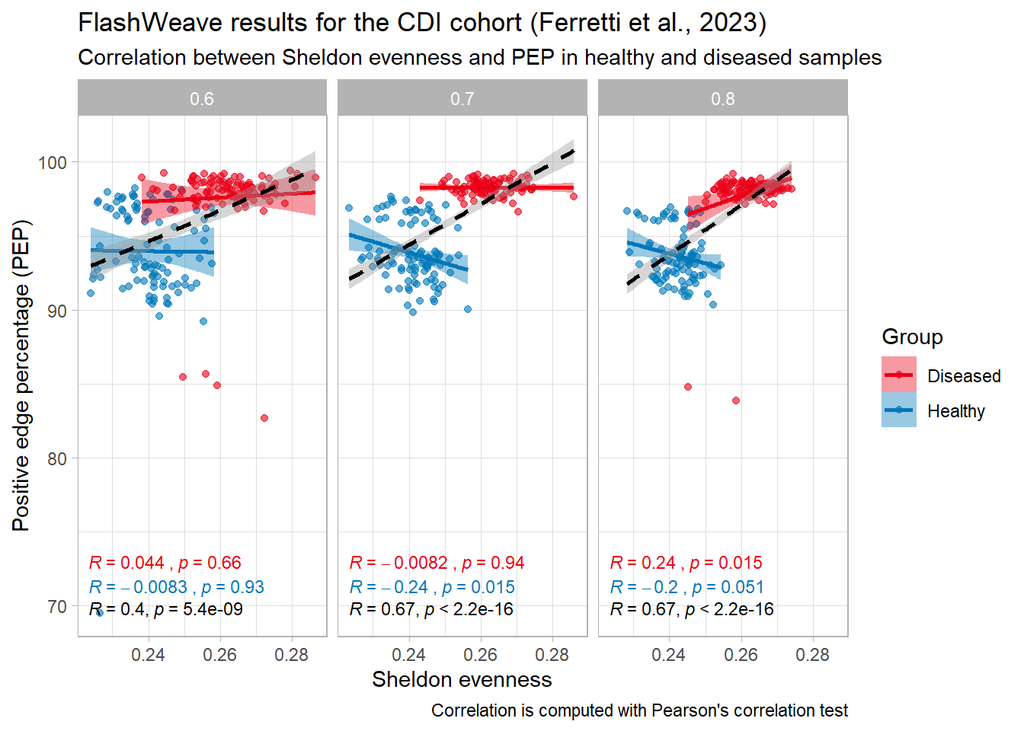

```r
plot_correlation_results(df_res, variable_name = "pep") + labs(x = "Sheldon evenness", y = "Positive edge percentage (PEP)", color = "Group", fill = "Group", title = "FlashWeave results for the CDI cohort (Ferretti et al., 2023)", subtitle = "Correlation between Sheldon evenness and PEP in healthy and diseased samples", caption = "Correlation is computed with Pearson's correlation test")
```

We also compute the net interactions (rho) in the healthy and diseased samples and compare it with PEP in the plot below.

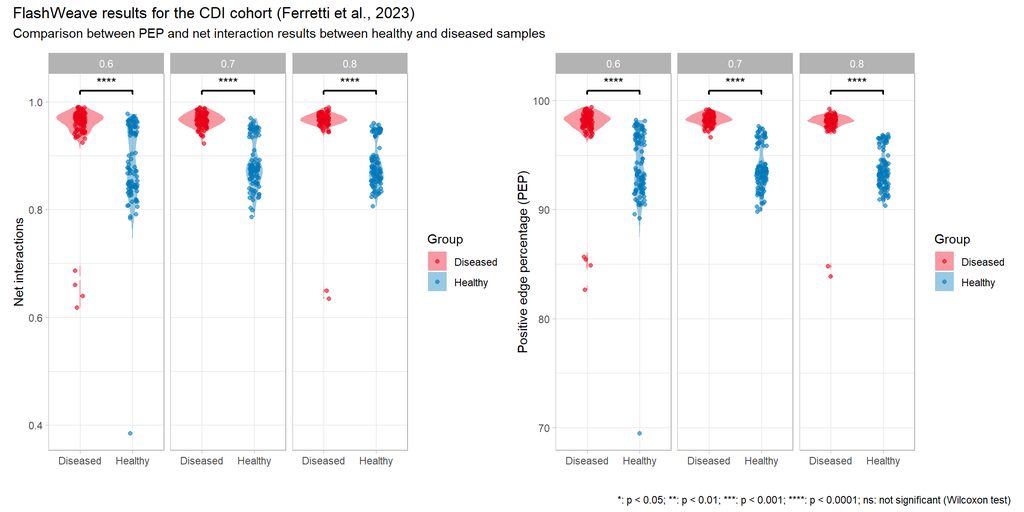

```r
plot_network_results(df_res) + plot_annotation(title = "FlashWeave results for the CDI cohort (Ferretti et al., 2023)", subtitle = "Comparison between PEP and net interaction results between healthy and diseased samples", caption = "*: p < 0.05; **: p < 0.01; ***: p < 0.001; ****: p < 0.0001; ns: not significant (Wilcoxon test)")
```

We check correlation between net interaction and Sheldon evenness in the plot below.

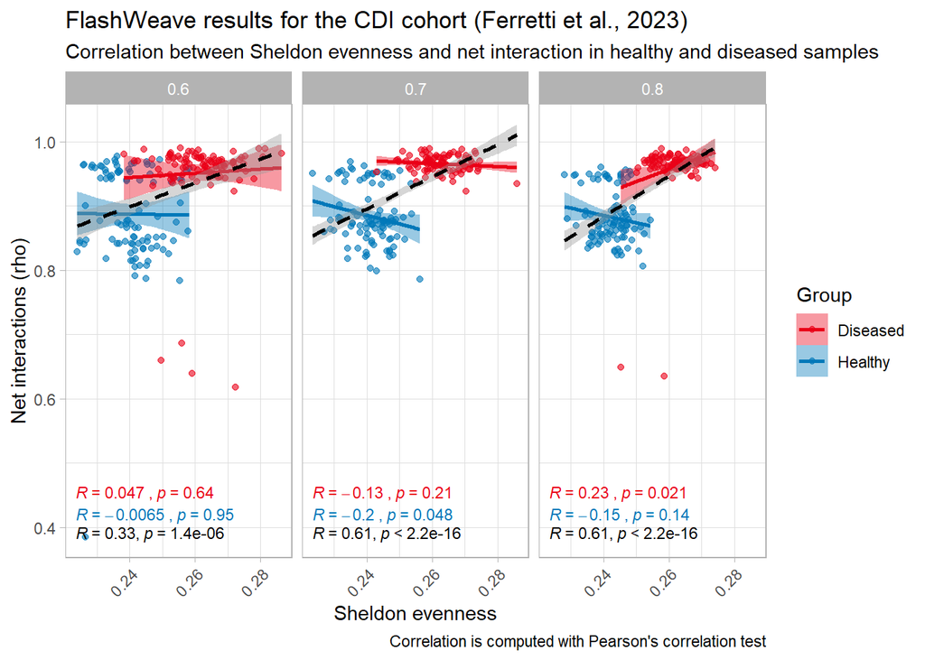

```r
plot_correlation_results(df_res, variable_name = "rho") + labs(x = "Sheldon evenness", y = "Net interactions (rho)", color = "Group", fill = "Group", title = "FlashWeave results for the CDI cohort (Ferretti et al., 2023)", subtitle = "Correlation between Sheldon evenness and net interaction in healthy and diseased samples", caption = "Correlation is computed with Pearson's correlation test") + theme(axis.text.x = element_text(angle = 45, hjust = 1))
```

## CRC cohort (Yachida et al., 2019)

```r
tmp <-
  mae[["CRC"]] |>
  assay() |>
  t() |>
  as.data.frame() |>
  rownames_to_column("uid") |>
  pivot_longer(-uid, names_to = "taxon", values_to = "count") |>
  group_by(uid) |>
  mutate(rel_ab = count/sum(count)) |>
  left_join(
    mae[["CRC"]] |> colData() |> as_tibble(rownames = "uid") |> select(uid, cohort),
    by = join_by(uid)
  )
```

```r
tmp_healthy <- tmp |> filter(cohort == "H")
tmp_diseased <- tmp |> filter(cohort == "CRC")

# for healthy samples

healthy_df <-
  tmp_healthy |>
  select(uid, taxon, rel_ab) |>
  pivot_wider(names_from = taxon, values_from = rel_ab) |>
  column_to_rownames("uid") |>
  t()

# for diseased samples

diseased_df <-
  tmp_diseased |>
  select(uid, taxon, rel_ab) |>
  pivot_wider(names_from = taxon, values_from = rel_ab) |>
  column_to_rownames("uid") |>
  t()
```

### FlashWeave

In the chunk code below, we run FlashWeave on all taxa for healthy and diseased samples separately, with the following parameters: `n_bootstrap = 100`, `subsample_pcts = c(0.6, 0.7, 0.8)`, `max_attempts = 120`. This means that in each bootstrap iteration, we will subsample the data at different percentages (60%, 70%, and 80%) and run FlashWeave on the subsampled data.

```r
res_healthy <- run_network_bootstrap(healthy_df, run_fn = run_flashweave, n_bootstrap = 100, subsample_pcts = c(0.6, 0.7, 0.8), max_attempts = 120, prevalence_threshold = 0)

saveRDS(res_healthy, file = str_c(result_dir(), "/flashweave_res_healthy_CRC_20260419.rds"))

beepr::beep(2)

res_diseased <- run_network_bootstrap(diseased_df, run_fn = run_flashweave, n_bootstrap = 100, subsample_pcts = c(0.6, 0.7, 0.8), max_attempts = 120, prevalence_threshold = 0)

saveRDS(res_diseased, file = str_c(result_dir(), "/flashweave_res_diseased_CRC_20260419.rds"))

beepr::beep(2)
```

We load the results in the chunk code below.

```r
res_healthy <- readRDS(file = str_c(result_dir(), "/flashweave_res_healthy_CRC_20260419.rds"))
res_diseased <- readRDS(file = str_c(result_dir(), "/flashweave_res_diseased_CRC_20260419.rds"))
```

```r
df_res_healthy <- get_stats_df(res_healthy, symmetric = TRUE)
df_res_diseased <- get_stats_df(res_diseased, symmetric = TRUE)

df_res <-
  bind_rows(
    df_res_healthy |> mutate(group = "Healthy"),
    df_res_diseased |> mutate(group = "Diseased")
  )
```

We plot the results below.

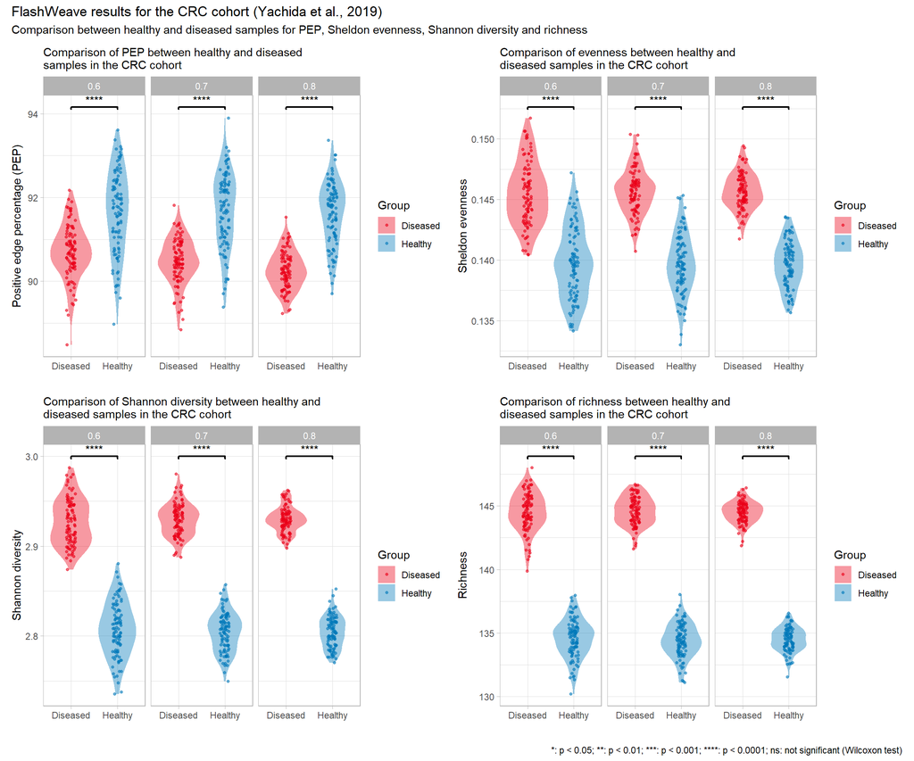

```r
plot_diversity_results(df_res, cohort_name = "CRC") + plot_annotation(title = "FlashWeave results for the CRC cohort (Yachida et al., 2019)", subtitle = "Comparison between healthy and diseased samples for PEP, Sheldon evenness, Shannon diversity and richness", caption = "*: p < 0.05; **: p < 0.01; ***: p < 0.001; ****: p < 0.0001; ns: not significant (Wilcoxon test)")
```

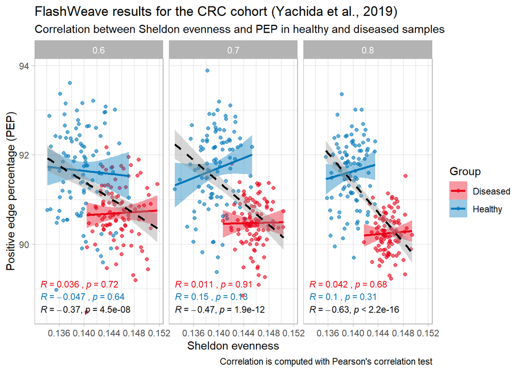

```r
plot_correlation_results(df_res, variable_name = "pep") + labs(x = "Sheldon evenness", y = "Positive edge percentage (PEP)", color = "Group", fill = "Group", title = "FlashWeave results for the CRC cohort (Yachida et al., 2019)", subtitle = "Correlation between Sheldon evenness and PEP in healthy and diseased samples", caption = "Correlation is computed with Pearson's correlation test")
```

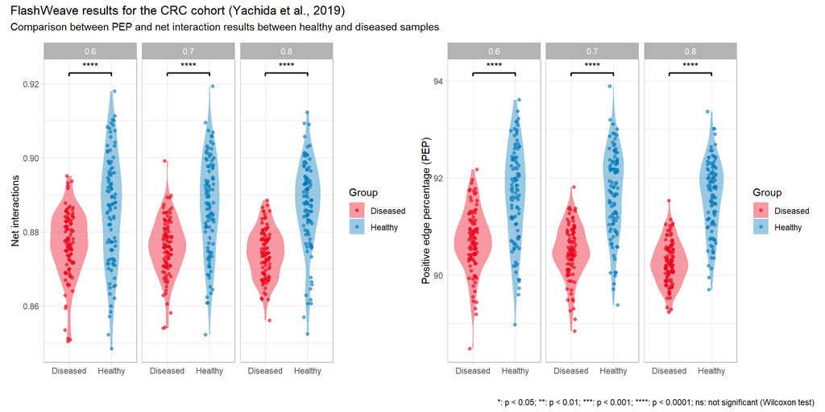

```r
plot_network_results(df_res) + plot_annotation(title = "FlashWeave results for the CRC cohort (Yachida et al., 2019)", subtitle = "Comparison between PEP and net interaction results between healthy and diseased samples", caption = "*: p < 0.05; **: p < 0.01; ***: p < 0.001; ****: p < 0.0001; ns: not significant (Wilcoxon test)")
```

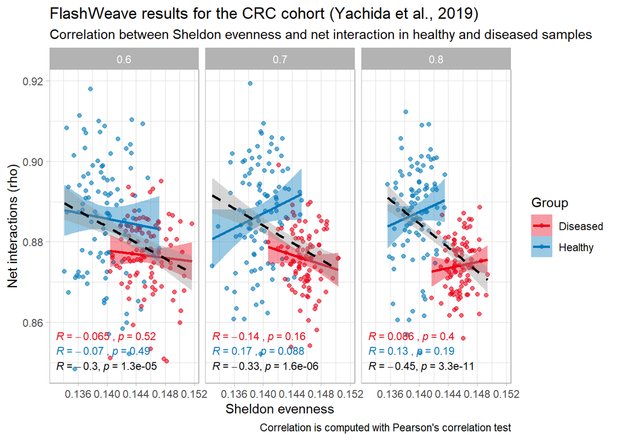

```r
plot_correlation_results(df_res, variable_name = "rho") + labs(x = "Sheldon evenness", y = "Net interactions (rho)", color = "Group", fill = "Group", title = "FlashWeave results for the CRC cohort (Yachida et al., 2019)", subtitle = "Correlation between Sheldon evenness and net interaction in healthy and diseased samples", caption = "Correlation is computed with Pearson's correlation test")
```

### BEEM-Static

```r
# import file from cluster

res_healthy <- readRDS(file = str_c(result_dir(), "/beem_res_healthy_CRC_20260428.rds"))
res_diseased <- readRDS(file = str_c(result_dir(), "/beem_res_diseased_CRC_20260428.rds"))
```

```r
df_res_healthy <- get_stats_df(res_healthy, symmetric = TRUE)
df_res_diseased <- get_stats_df(res_diseased, symmetric = TRUE)

df_res <-
  bind_rows(
    df_res_healthy |> mutate(group = "Healthy"),
    df_res_diseased |> mutate(group = "Diseased")
  )
```

We plot the results below.

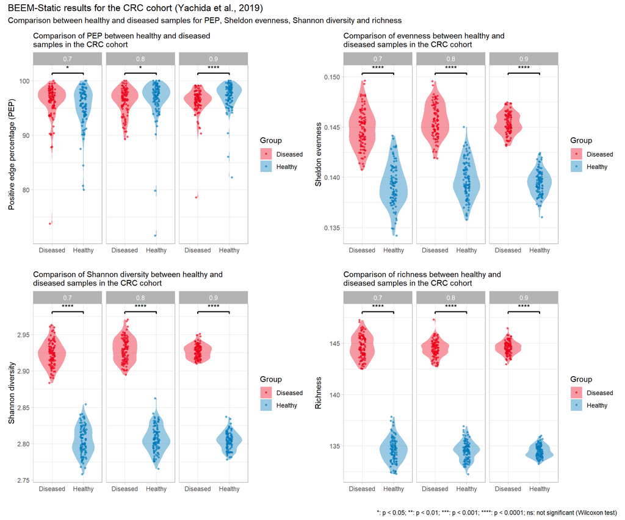

```r
plot_diversity_results(df_res, cohort_name = "CRC") + plot_annotation(title = "BEEM-Static results for the CRC cohort (Yachida et al., 2019)", subtitle = "Comparison between healthy and diseased samples for PEP, Sheldon evenness, Shannon diversity and richness", caption = "*: p < 0.05; **: p < 0.01; ***: p < 0.001; ****: p < 0.0001; ns: not significant (Wilcoxon test)")
```

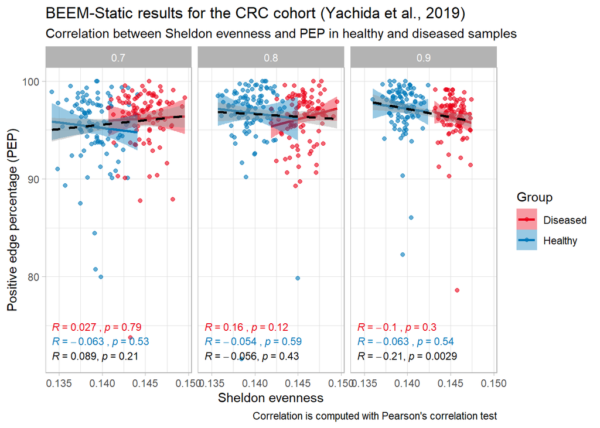

```r
plot_correlation_results(df_res, variable_name = "pep") + labs(x = "Sheldon evenness", y = "Positive edge percentage (PEP)", color = "Group", fill = "Group", title = "BEEM-Static results for the CRC cohort (Yachida et al., 2019)", subtitle = "Correlation between Sheldon evenness and PEP in healthy and diseased samples", caption = "Correlation is computed with Pearson's correlation test")
```

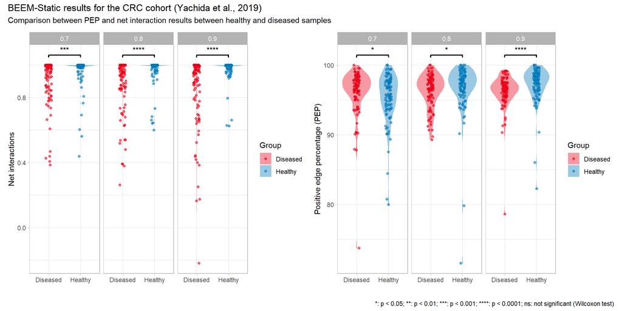

```r
plot_network_results(df_res) + plot_annotation(title = "BEEM-Static results for the CRC cohort (Yachida et al., 2019)", subtitle = "Comparison between PEP and net interaction results between healthy and diseased samples", caption = "*: p < 0.05; **: p < 0.01; ***: p < 0.001; ****: p < 0.0001; ns: not significant (Wilcoxon test)")
```

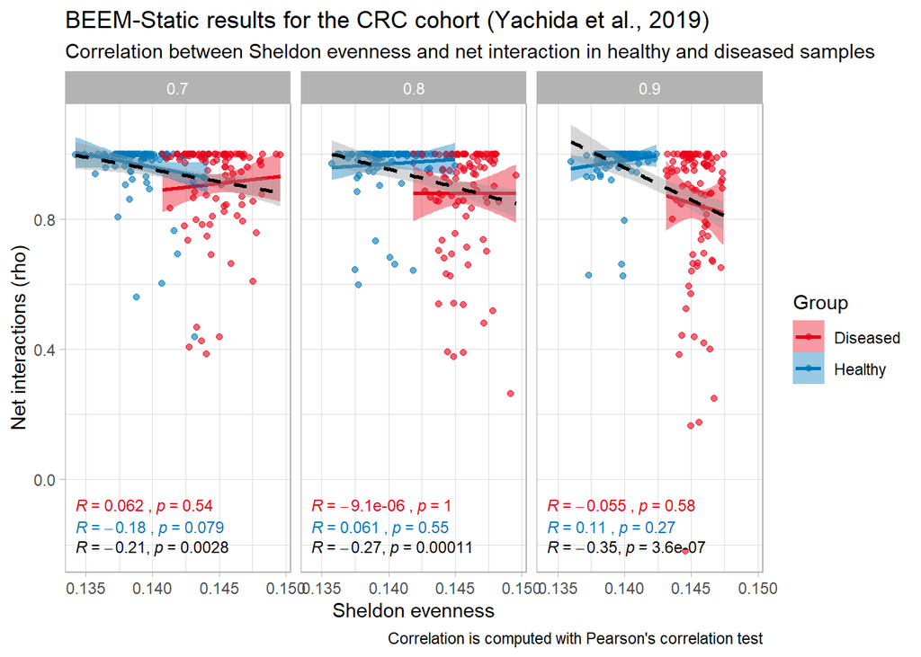

```r
plot_correlation_results(df_res, variable_name = "rho") + labs(x = "Sheldon evenness", y = "Net interactions (rho)", color = "Group", fill = "Group", title = "BEEM-Static results for the CRC cohort (Yachida et al., 2019)", subtitle = "Correlation between Sheldon evenness and net interaction in healthy and diseased samples", caption = "Correlation is computed with Pearson's correlation test")
```

# Network inference for supplementary cohorts

## IBD cohort (Franzosa et al., 2019)

```r
tmp <-
  mae[["IBD_FRANZOSA"]] |>
  assay() |>
  t() |>
  as.data.frame() |>
  rownames_to_column("uid") |>
  pivot_longer(-uid, names_to = "taxon", values_to = "rel_ab") |>
  # group_by(uid) |>
  # mutate(rel_ab = count/sum(count)) |>
  left_join(
    mae[["IBD_FRANZOSA"]] |> colData() |> as_tibble(rownames = "uid") |> select(uid, diagnosis),
    by = join_by(uid)
  )
```

```r
tmp_healthy <- tmp |> filter(diagnosis == "Control")
tmp_diseased <- tmp |> filter(diagnosis == "CD" | diagnosis == "UC")

# for healthy samples

healthy_df <-
  tmp_healthy |>
  select(uid, taxon, rel_ab) |>
  pivot_wider(names_from = taxon, values_from = rel_ab) |>
  column_to_rownames("uid") |>
  t()

# for diseased samples

diseased_df <-
  tmp_diseased |>
  select(uid, taxon, rel_ab) |>
  pivot_wider(names_from = taxon, values_from = rel_ab) |>
  column_to_rownames("uid") |>
  t()
```

### FlashWeave

In the chunk code below, we run FlashWeave on all taxa for healthy and diseased samples separately, with the following parameters: `n_bootstrap = 100`, `subsample_pcts = c(0.6, 0.7, 0.8)`, `max_attempts = 120`. This means that in each bootstrap iteration, we will subsample the data at different percentages (60%, 70%, and 80%) and run FlashWeave on the subsampled data.

```r
res_healthy <- run_network_bootstrap(healthy_df, run_fn = run_flashweave, n_bootstrap = 100, subsample_pcts = c(0.6, 0.7, 0.8), max_attempts = 120, prevalence_threshold = 0)

saveRDS(res_healthy, file = str_c(result_dir(), "/flashweave_res_healthy_IBD_franzosa_20260419.rds"))

beepr::beep(2)

res_diseased <- run_network_bootstrap(diseased_df, run_fn = run_flashweave, n_bootstrap = 100, subsample_pcts = c(0.6, 0.7, 0.8), max_attempts = 120, prevalence_threshold = 0)

saveRDS(res_diseased, file = str_c(result_dir(), "/flashweave_res_diseased_IBD_franzosa_20260419.rds"))

beepr::beep(2)
```

We load the results in the chunk code below.

```r
res_healthy <- readRDS(file = str_c(result_dir(), "/flashweave_res_healthy_IBD_franzosa_20260419.rds"))
res_diseased <- readRDS(file = str_c(result_dir(), "/flashweave_res_diseased_IBD_franzosa_20260419.rds"))
```

```r
df_res_healthy <- get_stats_df(res_healthy, symmetric = TRUE)
df_res_diseased <- get_stats_df(res_diseased, symmetric = TRUE)

df_res <-
  bind_rows(
    df_res_healthy |> mutate(group = "Healthy"),
    df_res_diseased |> mutate(group = "Diseased")
  )
```

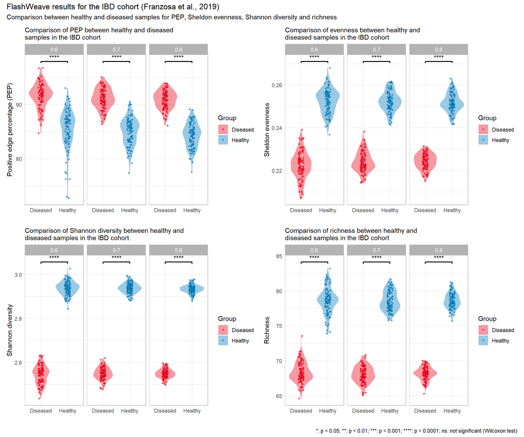

```r
plot_diversity_results(df_res, cohort_name = "IBD") + plot_annotation(title = "FlashWeave results for the IBD cohort (Franzosa et al., 2019)", subtitle = "Comparison between healthy and diseased samples for PEP, Sheldon evenness, Shannon diversity and richness", caption = "*: p < 0.05; **: p < 0.01; ***: p < 0.001; ****: p < 0.0001; ns: not significant (Wilcoxon test)")
```

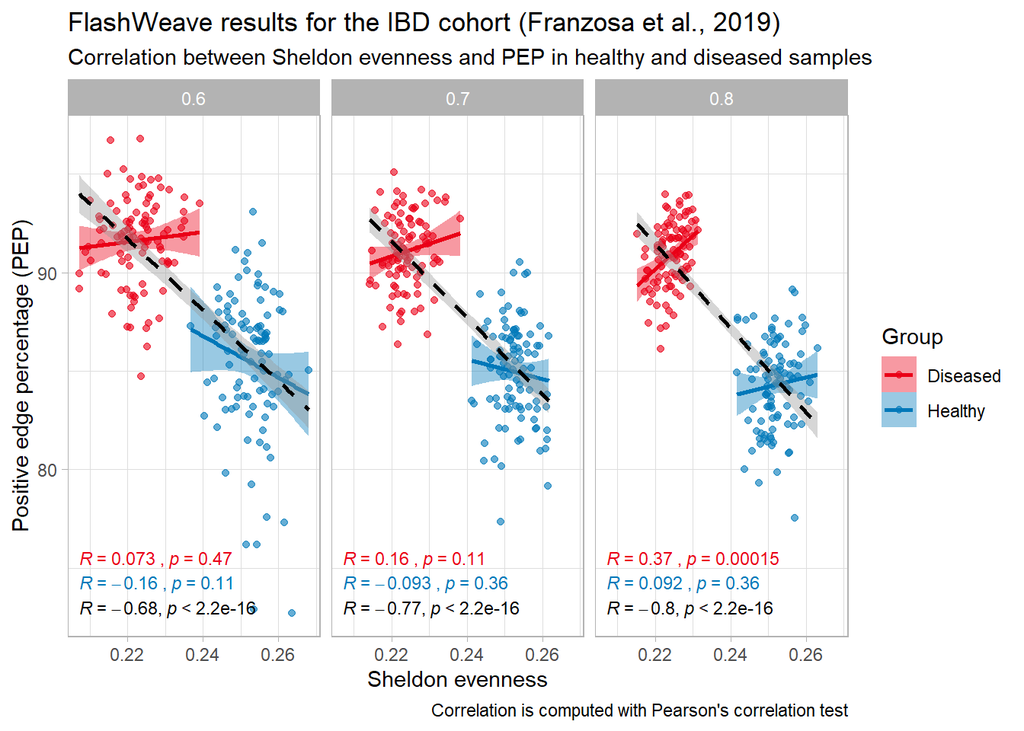

```r
plot_correlation_results(df_res, variable_name = "pep") + labs(x = "Sheldon evenness", y = "Positive edge percentage (PEP)", color = "Group", fill = "Group", title = "FlashWeave results for the IBD cohort (Franzosa et al., 2019)", subtitle = "Correlation between Sheldon evenness and PEP in healthy and diseased samples", caption = "Correlation is computed with Pearson's correlation test")
```

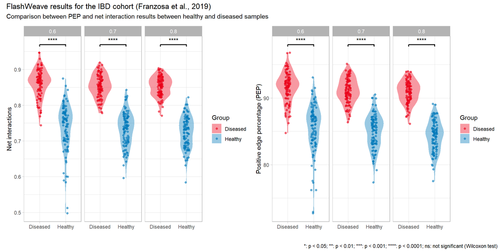

```r
plot_network_results(df_res) + plot_annotation(title = "FlashWeave results for the IBD cohort (Franzosa et al., 2019)", subtitle = "Comparison between PEP and net interaction results between healthy and diseased samples", caption = "*: p < 0.05; **: p < 0.01; ***: p < 0.001; ****: p < 0.0001; ns: not significant (Wilcoxon test)")
```

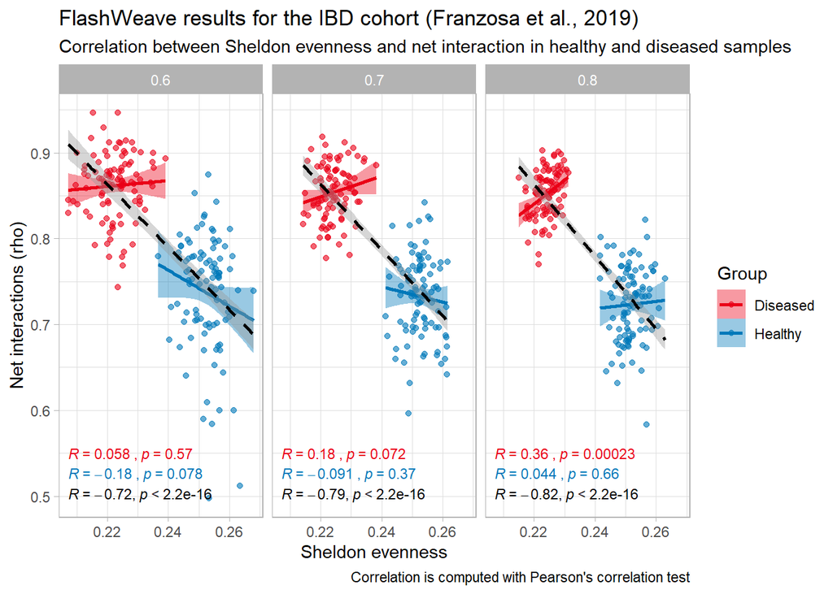

```r
plot_correlation_results(df_res, variable_name = "rho") + labs(x = "Sheldon evenness", y = "Net interactions (rho)", color = "Group", fill = "Group", title = "FlashWeave results for the IBD cohort (Franzosa et al., 2019)", subtitle = "Correlation between Sheldon evenness and net interaction in healthy and diseased samples", caption = "Correlation is computed with Pearson's correlation test")
```

## CRC cohort (Zeller et al., 2014)

```r
tmp <-
  mae[["CRC_ZELLER"]] |>
  assay() |>
  t() |>
  as.data.frame() |>
  rownames_to_column("uid") |>
  pivot_longer(-uid, names_to = "taxon", values_to = "count") |>
  group_by(uid) |>
  mutate(rel_ab = count/sum(count)) |>
  left_join(
    mae[["CRC_ZELLER"]] |> colData() |> as_tibble(rownames = "uid") |> select(uid, disease),
    by = join_by(uid)
  )
```

```r
tmp_healthy <- tmp |> filter(disease == "healthy")
tmp_diseased <- tmp |> filter(disease == "CRC")

# for healthy samples

healthy_df <-
  tmp_healthy |>
  select(uid, taxon, rel_ab) |>
  pivot_wider(names_from = taxon, values_from = rel_ab) |>
  column_to_rownames("uid") |>
  t()

# for diseased samples

diseased_df <-
  tmp_diseased |>
  select(uid, taxon, rel_ab) |>
  pivot_wider(names_from = taxon, values_from = rel_ab) |>
  column_to_rownames("uid") |>
  t()
```